# 売上数予測

田村 圭祐

## Pythonで機械学習実践

scikit-learnのLightGBMを使ってKaggleのコンペティション「Predict Future Sales」と言う1ヶ月後の売上数予測を実践します。  
また、Kagglerでも意外にやっている人が少ない「コーディングを綺麗に書く」ことも意識して作っています。 コーディングを綺麗に書くことで以下のメリットがあります。

・可読性の向上  
・どこのセルを何回実行しようともバグもエラーもでない  
・過去に実行したデータがどういった構造だったのか復習がしやすい  
・保守性の向上(コードの書き換えが楽になる)

実際のデータ分析でコーディングが汚いと上記の恩恵を受けれず、後で無駄な時間を消耗してしまいがちなのでコーディングは綺麗に書くことをオススメします。

## 時系列データ分析の流れ

以下が時系列データ分析の流れです。

1.データ読み込み  
2.データ理解  
3.データ加工  
4.データ分割とハイパーパラメータ設定  
5.機械学習とモデル評価  
6.データ予測

# 1.データ読み込み

パッケージやデータの読み込みをしていきます。

```python
# パッケージ読み込み
# Pythonバージョン 3.8.16
import numpy as np
import pandas as pd
import datetime
from plotnine import *    # 0.8.0 で動作確認済み。
from plotnine.themes import *
import warnings
import lightgbm as lgb
from sklearn.metrics import mean_squared_error
from sklearn.metrics import mean_absolute_error
from sklearn.model_selection import KFold
from matplotlib import pyplot as plt

# データフレームの表示行数を指定
pd.set_option('display.max_rows',5)

# 警告の非表示
warnings.filterwarnings('ignore')
```

```python
#データ読み込み
sales_train = pd.read_csv("/content/drive/MyDrive/Colab Notebooks/Kaggle/data/sales_train.csv")
sales_items = pd.read_csv("/content/drive/MyDrive/Colab Notebooks/Kaggle/data/items.csv")

# 各データを内部結合し一つにまとめる
df = pd.merge(sales_train, sales_items, on = "item_id")\
       .drop(columns = ["item_name"])

del sales_train, sales_items
```

# 2.データ理解

さっそく読み込んだデータを見てみましょう。 データの特徴量や基本統計量を確認したのち、可視化を通じてデータ構造を把握します。

```python
# データの確認
df
```

|  | date | date_block_num | shop_id | item_id | item_price | item_cnt_day | item_category_id |
| --- | --- | --- | --- | --- | --- | --- | --- |
| 0 | 02.01.2013 | 0 | 59 | 22154 | 999.0 | 1.0 | 37 |
| 1 | 23.01.2013 | 0 | 24 | 22154 | 999.0 | 1.0 | 37 |
| ... | ... | ... | ... | ... | ... | ... | ... |
| 2935847 | 22.10.2015 | 33 | 25 | 7635 | 2100.0 | 1.0 | 64 |
| 2935848 | 01.10.2015 | 33 | 25 | 7640 | 4040.0 | 1.0 | 64 |

2935849 rows × 7 columns

## 特徴量の説明

**主キー : date_block_num, shop_id, item_id**

※ 必ずしも全てのお店に全ての商品があるわけではありません。また特定の時期に全ての商品があるとも限りません。

```python
# 基本統計量
round(df.describe(),1)
```

|  | date_block_num | shop_id | item_id | item_price | item_cnt_day | item_category_id |
| --- | --- | --- | --- | --- | --- | --- |
| count | 2935849.0 | 2935849.0 | 2935849.0 | 2935849.0 | 2935849.0 | 2935849.0 |
| mean | 14.6 | 33.0 | 10197.2 | 890.9 | 1.2 | 40.0 |
| ... | ... | ... | ... | ... | ... | ... |
| 75% | 23.0 | 47.0 | 15684.0 | 999.0 | 1.0 | 55.0 |
| max | 33.0 | 59.0 | 22169.0 | 307980.0 | 2169.0 | 83.0 |

8 rows × 6 columns

## データの可視化

今回はデータを可視化するパッケージとして「plotnine」と言うパッケージを使います。  
plotnineは可視化を得意とするR言語でも高い人気を誇る「ggplot2」を模倣したパッケージです。  
少ない記述で簡単に可視化ができる優れものです。

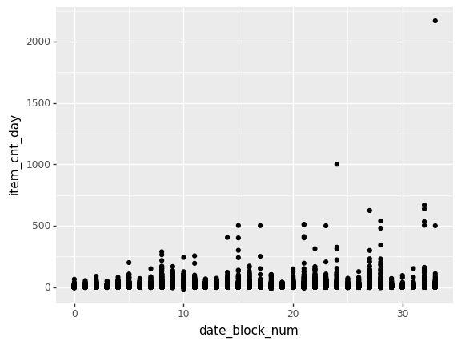

```python
# plotnineを使ったデータの可視化
ggplot(df, aes(x="date_block_num", y="item_cnt_day"))\
  +geom_point()
```

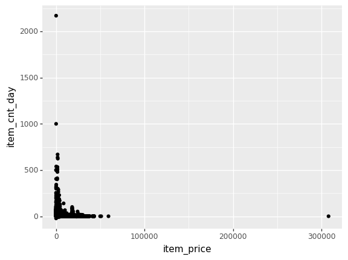

```python
ggplot(df, aes(x="item_price", y="item_cnt_day"))\
  +geom_point()
```

グラフを可視化すると、外れ値のせいでスケールが異様に大きいのが分かります。  
このままではデータ分析の精度を著しく損なうので、外れ値は対策をする必要があります。

# 3.データ加工

このチャプターでは前述の外れ値の置換はもちろん、特徴量の作成もしていきます。  
通称:前処理とも呼ばれ、全体の工数のおおよそ8割をこのデータ加工に費やします。  
今回は時系列データ分析なのでラグ特徴量という過去の情報を持つ特徴量も作成します。  
それではさっそく外れ値の置換からやってみましょう。

```python
# 外れ値の置換

# item_priceの外れ値置換用関数
def func_item_price(x):
  if x["item_id"] == 11365 and x["item_price"] == 59200:
    return 14530
  elif x["item_price"] > 59200:
    return 5000
  elif x["item_price"] <= 0:
    return 1
  else:
    return x["item_price"]

# assign関数で更新
df_1 = df.assign(
    item_cnt_day = lambda x:x[["item_cnt_day"]].clip(0, 100, axis=1) # clip関数で上限・下限を設定
   ,item_price = lambda x:x.apply(func_item_price, axis=1)           # 上記で作成した関数で置換
    )
```

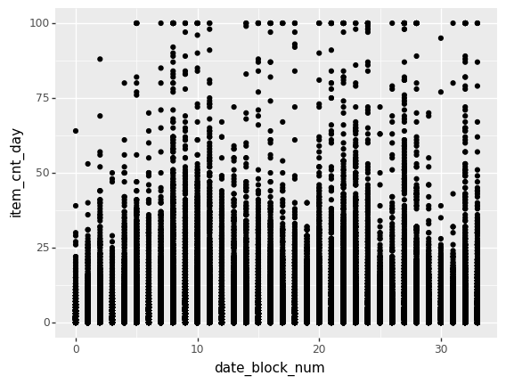

```python
# 外れ値削除後のデータ
ggplot(df_1, aes(x="date_block_num", y="item_cnt_day"))\
  +geom_point()
```

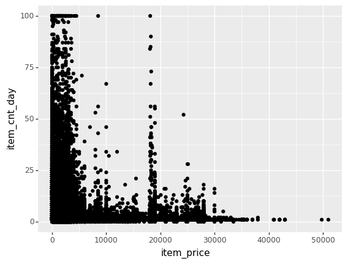

```python
ggplot(df_1, aes(x="item_price", y="item_cnt_day"))\
  +geom_point()
```

こちらも外れ値置換後はスケールが小さくなり、全体のデータの分布がおおよそ見えるようになりました。  
全体的に左下に偏った分布になっているのが確認できます。

## 日単位 → 月単位

現在のデータは日単位となっているので、月単位での処理ができるように データを月で丸めていきます。

```python
# 時系列データを月で丸める。

# item_priceは平均で、item_cnt_dayは合計丸める
df_group_item = df_1.groupby(["date_block_num", "shop_id", "item_id"], as_index=False)["item_price", "item_category_id", "item_cnt_day"]\
                    .agg({"item_price":"mean", "item_category_id":"mean", "item_cnt_day":"sum"})\
                    .rename(columns={'item_cnt_day': 'item_cnt_month'})  #目的変数:item_cnt_month

# dateは月に丸めてから年と月の特徴量を作成する
# (以下の処理をまとめて実行)
# ・データを必要な特徴量のみに絞る
# ・dateを日付型に変換
# ・dateをindexにセットする
# ・月単位でグループ化
# ・date_block_numの値が変わらないように平均でとる
# ・indexからdateを取り出す
# ・年の特徴量と月の特徴量作成(数値型)
# ・dateを削除
df_years_months = df_1.filter(["date","date_block_num"])\
                      .assign(date = lambda x:pd.to_datetime(x["date"],  format="%d.%m.%Y"))\
                      .set_index('date')\
                      .resample('M')\
                      .mean()\
                      .reset_index()\
                      .assign(
                          years = lambda x:[date.year for date in x["date"]]    # 年の特徴量作成
                        , months = lambda x:[date.month for date in x["date"]]  # 月の特徴量作成
                        )\
                      .drop(columns=["date"])  # 日付型はのちの学習に使えないのでここで削除

#作成した特徴量を1つに結合
df_2 = pd.merge(df_group_item, df_years_months, on = ["date_block_num"])\
         .assign(date_block_num = lambda x:x["date_block_num"] + 1)\
         .reindex(columns=["years", "months", "date_block_num", "shop_id", "item_id", "item_price", "item_category_id", "item_cnt_month"])

del df_group_item, df_years_months
```

以上で、データを月で丸める加工は完了です。  
ここで再度データを確認してみましょう。

```python
# データの確認
df_2
```

|  | years | months | date_block_num | shop_id | item_id | item_price | item_category_id | item_cnt_month |
| --- | --- | --- | --- | --- | --- | --- | --- | --- |
| 0 | 2013 | 1 | 1 | 0 | 32 | 221.0 | 40.0 | 6.0 |
| 1 | 2013 | 1 | 1 | 0 | 33 | 347.0 | 37.0 | 3.0 |
| ... | ... | ... | ... | ... | ... | ... | ... | ... |
| 1609122 | 2015 | 10 | 34 | 59 | 22100 | 629.0 | 42.0 | 1.0 |
| 1609123 | 2015 | 10 | 34 | 59 | 22102 | 1250.0 | 42.0 | 1.0 |

1609124 rows × 8 columns

```python
# 基本統計量
round(df_2.describe(),1)
```

|  | years | months | date_block_num | shop_id | item_id | item_price | item_category_id | item_cnt_month |
| --- | --- | --- | --- | --- | --- | --- | --- | --- |
| count | 1609124.0 | 1609124.0 | 1609124.0 | 1609124.0 | 1609124.0 | 1609124.0 | 1609124.0 | 1609124.0 |
| mean | 2013.8 | 6.2 | 15.7 | 32.8 | 10681.0 | 790.7 | 41.5 | 2.3 |
| ... | ... | ... | ... | ... | ... | ... | ... | ... |
| 75% | 2014.0 | 9.0 | 24.0 | 47.0 | 16060.0 | 898.5 | 55.0 | 2.0 |
| max | 2015.0 | 12.0 | 34.0 | 59.0 | 22169.0 | 50999.0 | 83.0 | 1305.0 |

8 rows × 8 columns

[figure not shown]

```python
# 各月の売上数合計を可視化

# 各月の売上数合計
df_item_cnt_sum = df_2.groupby(["date_block_num"], as_index=False)["item_cnt_month"]\
                      .sum()

# 売上数合計が黒、12ヶ月移動平均が赤
ggplot(aes(x = "date_block_num", y = "item_cnt_month"))\
  +geom_line(df_item_cnt_sum)\
  +geom_line(df_item_cnt_sum.rolling(window=12,center=False).mean(), colour="red")
```

このように時系列データを可視化すると以下の特徴を確認することができます。

・トレンド : 時間の経過とともに増加または減少をする  
・季節変動 : 季節ごとに繰り返される変動  
・循環変動 : 季節変動よりも長い期間または周期で変動  
・不規則変動 : 上3つに当てはまらない変動

## 特徴量作成

ここまでで外れ値の置換や日付のグループ化で下地は整ったので、本格的に特徴量を作成していきます。  
ここでは様々な組み合わせでグループ化をしたり、基本統計量を取得したり、掛け合わせをしたりすることで多様な特徴量を作成します。

```python
# 特徴量作成

# カテゴリーごとの平均の値段、売上数、売上の3つを作成
df_category = df_2.groupby(["date_block_num","shop_id","item_category_id"], as_index=False)["item_price", "item_cnt_month"]\
                  .agg({"item_price":"mean", "item_cnt_month":"sum"})\
                  .rename(columns = {"item_price": "category_price", "item_cnt_month": "category_cnt_month"})\
                  .assign(category_sales = lambda x:x["category_price"] * x["category_cnt_month"])

# お店の商品の売上
df_shop_item_sales = df_2.filter(["date_block_num", "shop_id", "item_id", "item_price" ,"item_cnt_month"])\
                         .assign(shop_item_sales = lambda x:x["item_price"] * x["item_cnt_month"])\
                         .drop(columns = ["item_price", "item_cnt_month"])

# お店ごとの売上合計
df_shop_sales = df_shop_item_sales.groupby(["date_block_num", "shop_id"], as_index=False)["shop_item_sales"]\
                                  .sum()\
                                  .rename(columns={"shop_item_sales": "shop_sales"})

# 商品の平均額
df_item_price_mean = df_2.groupby(["date_block_num", "item_id"], as_index=False)["item_price"]\
                         .mean()\
                         .rename(columns={"item_price": "item_price_mean"})

# 作成した特徴量を1つに結合
df_3 = pd.merge(df_2, df_category, on = ["date_block_num", "shop_id", "item_category_id"])\
         .merge(df_shop_item_sales, on = ["date_block_num", "shop_id", "item_id"])\
         .merge(df_shop_sales, on = ["date_block_num", "shop_id"])\
         .merge(df_item_price_mean, on = ["date_block_num", "item_id"])

del df_category, df_shop_item_sales, df_shop_sales, df_item_price_mean
```

ここで一旦特徴量の作成を区切ります。  
再度データを確認してみましょう。

```python
# データの確認
round(df_3,1)
```

|  | years | months | date_block_num | shop_id | item_id | item_price | item_category_id | item_cnt_month | category_cnt_month | category_price | shop_item_sales | shop_sales | item_price_mean | category_sales |
| --- | --- | --- | --- | --- | --- | --- | --- | --- | --- | --- | --- | --- | --- | --- |
| 0 | 2013 | 1 | 1 | 0 | 32 | 221.0 | 40.0 | 6.0 | 1838.0 | 133.6 | 1326.0 | 2966061.4 | 335.0 | 245576.0 |
| 1 | 2013 | 1 | 1 | 1 | 32 | 221.0 | 40.0 | 7.0 | 983.0 | 126.4 | 1547.0 | 1527037.2 | 335.0 | 124289.3 |
| ... | ... | ... | ... | ... | ... | ... | ... | ... | ... | ... | ... | ... | ... | ... |
| 1609122 | 2015 | 10 | 34 | 59 | 5662 | 398.0 | 3.0 | 1.0 | 13.0 | 2173.8 | 398.0 | 974810.3 | 398.0 | 28259.1 |
| 1609123 | 2015 | 10 | 34 | 59 | 20392 | 2199.0 | 72.0 | 1.0 | 13.0 | 1221.2 | 2199.0 | 974810.3 | 2199.0 | 15875.9 |

1609124 rows × 14 columns

```python
# 基本統計量
round(df_3.describe(),1)
```

|  | years | months | date_block_num | shop_id | item_id | item_price | item_category_id | item_cnt_month | category_cnt_month | category_price | category_sales | sales | shop_sales | item_price_mean |
| --- | --- | --- | --- | --- | --- | --- | --- | --- | --- | --- | --- | --- | --- | --- |
| count | 1609124.0 | 1609124.0 | 1609124.0 | 1609124.0 | 1609124.0 | 1609124.0 | 1609124.0 | 1609124.0 | 1609124.0 | 1609124.0 | 1609124.0 | 1609124.0 | 1609124.0 | 1609124.0 |
| mean | 2013.8 | 6.2 | 15.7 | 32.8 | 10681.0 | 790.7 | 41.5 | 2.3 | 321.6 | 790.7 | 126908.3 | 2114.4 | 2941772.8 | 790.7 |
| ... | ... | ... | ... | ... | ... | ... | ... | ... | ... | ... | ... | ... | ... | ... |
| 75% | 2014.0 | 9.0 | 24.0 | 47.0 | 16060.0 | 898.5 | 55.0 | 2.0 | 369.0 | 1032.6 | 159821.7 | 1494.0 | 4061426.9 | 882.5 |
| max | 2015.0 | 12.0 | 34.0 | 59.0 | 22169.0 | 50999.0 | 83.0 | 1305.0 | 4301.0 | 42990.0 | 6212879.8 | 6212879.8 | 15739742.1 | 50999.0 |

8 rows × 14 columns

## ラグ特徴量作成

次に、ラグ特徴量を作成していきます。  
ラグ特徴量は時系列データにおいて過去の情報を持つ特徴量のことを言います。  
通常はshift関数で行の並び順をズラすことでラグ特徴量を作成します。  
しかし、今回はデータが日付だけでなくshop_id、item_idとも主キーになっているので、単純に行の並び順をズラして作成はできません。  
そこで、1月ずつデータを区切り、ラグ特徴量を作成し、最後に区切ったデータを元のデータと結合する方法でラグ特徴量を作成します。

```python
# ラグ特徴量作成

# ラグ特徴量作成用関数
def func_lag(x, j): # x:特徴量, j:ラグの期間
  tmp_before = df_3.query("date_block_num ==  @i - @j")\
                   .filter(["shop_id", "item_id", x])\
                   .rename(columns = {x: x + "_" + str(j)})  # query関数は条件文でデータを簡単に指定できるのでオススメです。
  return pd.merge(tmp_now, tmp_before, on = ["shop_id", "item_id"], how="left")

# ラグ特徴量作成開始
tmp = pd.DataFrame()
for i in range(1,max(df_3["date_block_num"] + 1)):
  tmp_now = df_3.filter(["date_block_num", "shop_id", "item_id"])\
                .query("date_block_num ==  @i")

  # 過去3ヶ月間のラグ特徴量
  for j in range(1, 4):
    tmp_now = func_lag("item_price", j)
    tmp_now = func_lag("category_cnt_month", j)
    tmp_now = func_lag("category_price", j)
    tmp_now = func_lag("category_sales", j)
    tmp_now = func_lag("shop_item_sales", j)
    tmp_now = func_lag("shop_sales", j)

  # 過去6ヶ月間のラグ特徴量
  for j in range(1, 7):
    tmp_now = func_lag("item_cnt_month", j)

  # 各月ごとのデータを縦結合して1つにまとめる
  tmp = pd.concat(
    [tmp, tmp_now]
    ,ignore_index = True
    )
  del tmp_now

# 以下の処理をまとめて実行
# ・ラグ特徴量を結合
# ・リークしている特徴量削除
# ・値段の変化率の特徴量作成
# ・欠損値を0に置換
# ・小数点第二位を四捨五入
data = round(
    pd.merge(df_3, tmp, on = ["date_block_num", "shop_id", "item_id"])\
      .drop(columns=["category_cnt_month", "category_sales", "shop_item_sales", "shop_sales"])\
      .assign(item_price_rate = lambda x:(x["item_price"] - x["item_price_1"]) / x["item_price_1"] * 100)\
      .fillna(0)
      ,1)

del tmp, i
```

データ加工はこれにて以上になります。 salesなどの4つの特徴量を削除しておりますが、これはリークと言う現象を防ぐためです。これらは目的変数であるitem_cnt_monthが分かる前提でできた特徴量のため、本来なら知りえない情報から不正に情報を得てしまうリスクがあります。ただ、ラグ特徴量の場合は過去の情報のため、今回は学習に使用しても問題ありません。  
それでは最後にデータを確認してみましょう。

```python
# データの確認
data
```

|  | years | months | date_block_num | shop_id | item_id | item_price | item_category_id | item_cnt_month | category_price | item_price_mean | ... | category_sales_3 | shop_item_sales_3 | shop_sales_3 | item_cnt_month_1 | item_cnt_month_2 | item_cnt_month_3 | item_cnt_month_4 | item_cnt_month_5 | item_cnt_month_6 | item_price_rate |
| --- | --- | --- | --- | --- | --- | --- | --- | --- | --- | --- | --- | --- | --- | --- | --- | --- | --- | --- | --- | --- | --- |
| 0 | 2013 | 1 | 1 | 0 | 32 | 221.0 | 40.0 | 6.0 | 133.6 | 335.0 | ... | 0.0 | 0.0 | 0.0 | 0.0 | 0.0 | 0.0 | 0.0 | 0.0 | 0.0 | 0.0 |
| 1 | 2013 | 1 | 1 | 1 | 32 | 221.0 | 40.0 | 7.0 | 126.4 | 335.0 | ... | 0.0 | 0.0 | 0.0 | 0.0 | 0.0 | 0.0 | 0.0 | 0.0 | 0.0 | 0.0 |
| ... | ... | ... | ... | ... | ... | ... | ... | ... | ... | ... | ... | ... | ... | ... | ... | ... | ... | ... | ... | ... | ... |
| 1609122 | 2015 | 10 | 34 | 59 | 5662 | 398.0 | 3.0 | 1.0 | 2173.8 | 398.0 | ... | 0.0 | 0.0 | 0.0 | 0.0 | 0.0 | 0.0 | 0.0 | 0.0 | 0.0 | 0.0 |
| 1609123 | 2015 | 10 | 34 | 59 | 20392 | 2199.0 | 72.0 | 1.0 | 1221.2 | 2199.0 | ... | 0.0 | 0.0 | 0.0 | 0.0 | 0.0 | 0.0 | 1.0 | 1.0 | 0.0 | 0.0 |

1609124 rows × 35 columns

# 4.データ分割とハイパーパラメータ設定

機械学習をする前段階としてデータの分割とハイパーパラメータの設定を行います。  
ハイパーパラメータを設定することで機械学習が効率的に学習を行えます。  
データ分割では学習データとテストデータの2つに分割を行います。  
そこからさらに訓練データ(_x)と教師データ(_y)にも分割をしていきます。

```python
#データを学習データとテストデータに分割する。
target = "item_cnt_month"
train = data.query("date_block_num < 34")
test = data.query("date_block_num == 34")  # 1ヶ月分をテストデータにする。
test_x = test.drop(columns = [target])     # 訓練データは目的変数を削除して作成する
test_y = test.filter([target])             # 教師データは目的変数のみにする
```

```python
# ハイパーパラメータの設定
params = {
  "objective": "regression"                 # 目的関数(回帰や分類などのタスクを指定)
  ,"metric": "mae"                          # 評価指標
  ,"num_leaves": 256                        # 葉の数
  ,"learning_rate": 0.05                    # 学習率
  ,"bagging_fraction": 0.8708633314341822   # 学習データから使用するサンプルの割合
  ,"bagging_freq": 1                        # baggingの頻度
  ,"feature_fraction": 0.5                  # 決定木から抽出される標本の割合
  ,'feature_pre_filter': False              # min_data_in_leaf=min_child_samplesのチューニングの可否
  ,"lambda_l1": 0.31808971970453737         # L1正則化
  ,"lambda_l2": 0.0019040142825237783       # L2正則化
  ,"early_stopping_round": None             # 評価関数の改善が指定した回数分見られなかったら学習を打ち止め
  ,"seed": 100                              # シード値
  }
```

# 5.機械学習とモデル評価

いよいよ機械学習をやっていきます。  
今回はLightGBMというGBDTアルゴリズムで機械学習をしていきます。  
モデル評価には回帰分析で一般的な平均絶対値誤差(MAE)を使います。  
また、学習データは交差検証（クロスバリデーション）という方法で分析をしていきます。  
交差検証とは学習データをさらに複数のデータ(fold)に分割して評価を行う手法です。  
時系列データの交差検証は以下のようなイメージで行います。

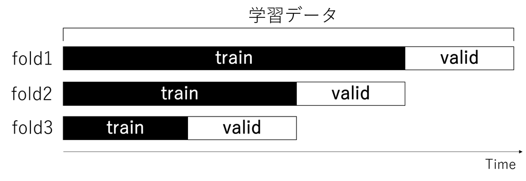

それでは、早速LightGBMのクラスを作っていきましょう。

```python
class lgb_model:
  def __init__(self):
    # モデルと結果を保存するための変数を用意する
    self.model = None
    self.results_dict = {}
    self.va_scores = []

  def trains(self, num_round, va_period_list):
    for va_period in va_period_list:

      # 学習データを訓練データと検証データに分割する。
      is_tr = "date_block_num < @va_period"
      is_va = "date_block_num == @va_period "  #テストデータに合わせて検証データも1ヶ月分にする。
      tr_x = train.query(is_tr).drop(columns=[target])
      tr_y = train.query(is_tr).filter([target])
      va_x = train.query(is_va).drop(columns=[target])
      va_y = train.query(is_va).filter([target])

      # 特徴量と目的変数をLightGBMのデータ構造に変換する
      lgb_train = lgb.Dataset(tr_x, tr_y)
      lgb_eval = lgb.Dataset(va_x, va_y)
      num_round = num_round  # 学習回数

      # 学習の実行
      # 検証データもモデルに渡し、学習の進行とともにスコアがどう変わるかモニタリングする
      self.model = lgb.train(
          params
          ,lgb_train
          ,num_boost_round = num_round
          ,valid_names = ["train", "valid"]
          ,valid_sets = [lgb_train, lgb_eval]
          ,evals_result = self.results_dict
        )

      # バリデーションデータでのスコアの確認
      va_pred = self.model.predict(va_x)
      va_score = mean_absolute_error(va_y, va_pred)
      self.va_scores.append(va_score)

  def predict(self, predict_data):
      return np.round(self.model.predict(predict_data))   # 小数点第一位を四捨五入
```

LightGBMのクラスが出来上がりました。  
このクラスを使って、いよいよ機械学習を始めます。  
まずは、学習データを25ヵ月分、29ヵ月分、33ヵ月分で交差検証をしていきます。

```python
# LightGBMを使った学習1回目
lgb_model_1 = lgb_model()
lgb_model_1.trains(num_round = 300, va_period_list = [25, 29, 33])
```

```python
# 検証データのスコア
lgb_model_1.va_scores
```

```
[1.2124821053412778, 1.1776416667245422, 1.2712580826304007]
```

検証データのスコア(MAE)は小さいほど誤差が小さく精度が良いことを表します。  
これを見ると29ヵ月分の学習データが最も精度が良いようです。

次に、特徴量の重要度がどうなっているのか確認してみましょう。

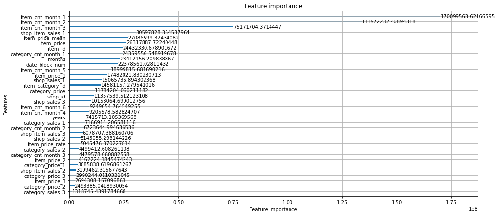

```python
# 性能向上に寄与する度合いで特徴量の重要度をプロットする
_, ax = plt.subplots(figsize=(15, 7))
lgb.plot_importance(
    lgb_model_1.model
   ,ax=ax
   ,importance_type='gain'
   )
plt.show()
```

このグラフから分かる通り、時系列データはラグ特徴量が重要になります。  
特に直近の目的変数のラグ特徴量は重要度が非常に高いです。

次に29ヵ月分の学習データを用いてモデルを作ると同時に学習曲線を見ていきましょう。  
学習曲線はモデルの学習を可視化することができます。

```python
# LightGBMを使った学習2回目
lgb_model_2 = lgb_model()
lgb_model_2.trains(num_round = 300, va_period_list = [29])
```

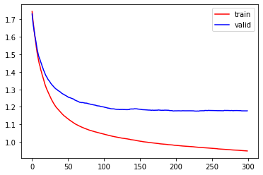

```python
# 学習曲線
plt.plot(lgb_model_2.results_dict["train"]["l1"], color = "red", label = "train")
plt.plot(lgb_model_2.results_dict["valid"]["l1"], color = "blue", label = "valid")
plt.legend()
plt.show()
```

学習が進むにつれて検証データのスコアと訓練データのスコアの差が開いていくのが分かると思います。  
この差が過学習という、モデルの汎化性能を低下させ未知の値の予測精度を下げてしまう原因になります。  
グラフを見ると学習回数が100を超えたあたりから検証データのスコアの改善があまり見られなくなっています。  
つまり、100回で学習を打ち切れば過学習を抑えつつ精度の良いモデルができることが分かります。  
これを踏まえて、再度モデルを作りましょう。

```python
# LightGBMを使った学習3回目
lgb_model_3 = lgb_model()
lgb_model_3.trains(num_round = 100, va_period_list = [29])
```

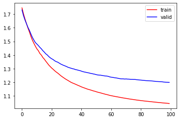

```python
# 学習曲線
plt.plot(lgb_model_3.results_dict["train"]["l1"], color = "red", label = "train")
plt.plot(lgb_model_3.results_dict["valid"]["l1"], color = "blue", label = "valid")
plt.legend()
plt.show()
```

これで丁度良いモデルが出来上がりました。

# 6.データ予測

先ほどのlgb_model_3を使ってテストデータを予測してみましょう。

```python
# テストデータの予測
test_pred = lgb_model_3.predict(test_x)
test_scores = mean_absolute_error(test_y, test_pred)
test_scores
```

```
1.197900478893787
```

テストデータの予測ができました。  
検証データの時と比較するとスコアが少し悪化しているのが分かると思います。  
未知の値を予測すると、検証データの時のスコアよりもどうしてもスコアは悪化しやすいです。  
では予測したitem_cnt_monthをグラフでも確認してみましょう。

```python
# 予測データと教師データをグラフで確認

# 予測データ
after_data = data.filter(["date_block_num", "shop_id", "item_id"])\
                 .query("date_block_num ==  34")\
                 .assign(item_cnt_month_pred = test_pred)\
                 .merge(data, on = ["date_block_num", "shop_id", "item_id"], how="right")\
                 .assign(
                     item_cnt_month = lambda x:np.where(
                         x["date_block_num"] == 34
                         ,x["item_cnt_month_pred"]
                         ,x["item_cnt_month"]
                     )
                 )\
                 .drop(columns=["item_cnt_month_pred"])\
                 .groupby(["date_block_num"], as_index=False)["item_cnt_month"]\
                 .sum()\
                 .query("33 <= date_block_num < 35")

# 教師データ
before_data = data.groupby(["date_block_num"], as_index=False)["item_cnt_month"]\
                  .sum()
```

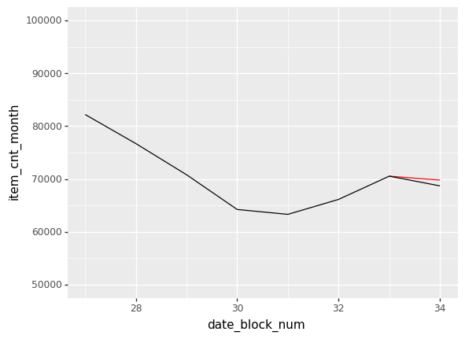

```python
# 赤が予測データ、黒が教師データ
ggplot()\
  +geom_line(after_data, aes(x = "date_block_num", y = "item_cnt_month"), colour = "red")\
  +geom_line(before_data, aes(x = "date_block_num", y = "item_cnt_month"))\
  +xlim(27, 34)\
  +ylim(50000, 100000)
```

完璧に一致しているとまではいかずとも、おおむね予測できていますね。  
長くなりましたがこれにて売上数予測は以上になります。  
時系列データ分析はGBDT以外にも、自己回帰和分移動平均（ARIMA）、Prophetなどメジャーな分析手法があります。  
これらは今回のような特徴量が少ないデータでも高精度な予測が可能です。  
もし機会があれば是非チャレンジしてみてください。

## 最後に

時系列データ分析はこれでお終いです。  
データ加工が大半を占める分析となりましたが、逆に言えばそれだけデータ加工は分析において重要です。  
そして、私がこの分析を通じて実は一番伝えたかったことは「コードを綺麗に書く」ことです。  
データ加工は重要で大半を占めるからこそ、そこでコードが汚いとせっかくのデータ加工の効率が大きく下がってしまいます。  
コードを綺麗に書くだけで自分のためだけでなく他人の為にもなります。  
もしこれを機に、今後のデータ分析の役に立って頂けたなら幸いです。  
ご一読ありがとうございました。

## 参考文献

・Kaggleで勝つデータ分析の技術 株式会社技術評論社 門脇大輔ら  
・Python実践データ分析100本ノック 株式会社秀和システム 齋藤 和邦  
・AIエンジニアが教えるPythonによるデータの前処理 Udemy shun